# Paper Rank

## Read Data

Read data and transfer the class of it’s date column from factor to date

```r
paperrank <- read.table("activity 2.csv", quote = "",sep = ",", header = TRUE)
paperrank <- transform(paperrank, X.date. = as.Date(as.character(X.date.),
                                                    format = "\"%Y-%m-%d\""))
summary(paperrank)
```

```
##     X.steps.         X.date.            X.interval.
##  Min.   :  0.00   Min.   :2012-10-01   Min.   :   0.0
##  1st Qu.:  0.00   1st Qu.:2012-10-16   1st Qu.: 588.8
##  Median :  0.00   Median :2012-10-31   Median :1177.5
##  Mean   : 37.38   Mean   :2012-10-31   Mean   :1177.5
##  3rd Qu.: 12.00   3rd Qu.:2012-11-15   3rd Qu.:1766.2
##  Max.   :806.00   Max.   :2012-11-30   Max.   :2355.0
##  NA's   :2304
```

## First Question: what is mean total number of steps taken per day?

Calculate the total steps each day

```r
library(dplyr)
```

```r
library(ggplot2)
paperrank <- tbl_df(paperrank)
totalstep <- paperrank %>%
        filter(!is.na(X.steps.)) %>%
        group_by(X.date.) %>%
        summarize( totalstep = sum(X.steps.))
totalstep
```

```
## # A tibble: 53 x 2
##       X.date. totalstep
##        <date>     <int>
## 1  2012-10-02       126
## 2  2012-10-03     11352
## 3  2012-10-04     12116
## 4  2012-10-05     13294
## 5  2012-10-06     15420
## 6  2012-10-07     11015
## 7  2012-10-09     12811
## 8  2012-10-10      9900
## 9  2012-10-11     10304
## 10 2012-10-12     17382
## # ... with 43 more rows
```

Draw the histogram of total steps

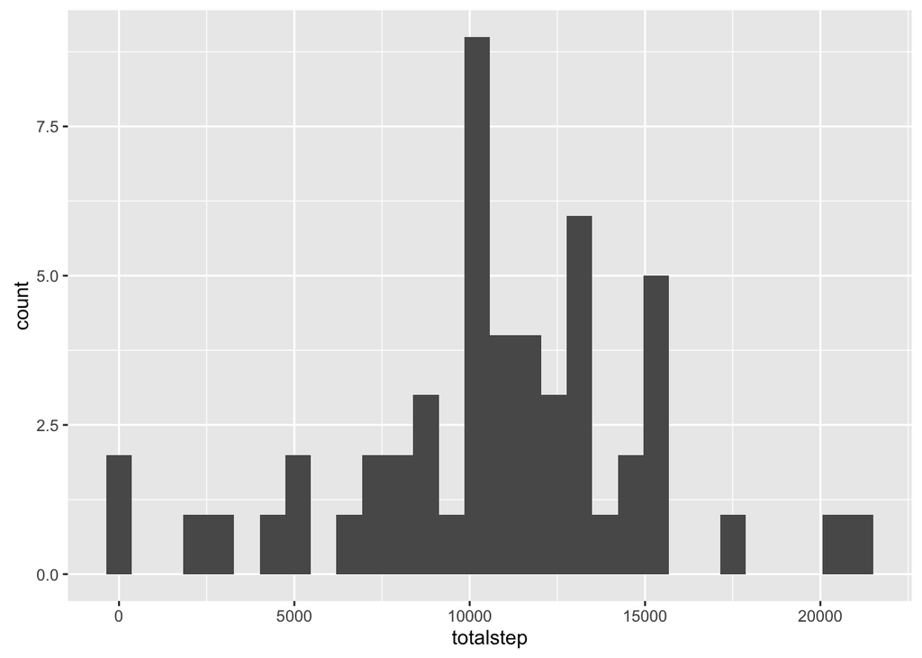

```r
g <- ggplot(totalstep,aes(totalstep))
g + geom_histogram()
```

Calculate the mean step

```r
meanstep <- as.numeric(summarize(totalstep, mean = mean(totalstep)))
meanstep
```

```
## [1] 10766.19
```

Calculate the median step

```r
medianstep <- as.numeric(summarize(totalstep, medain = median(totalstep)))
medianstep
```

```
## [1] 10765
```

## Second question: What is the average daily activity pattern?

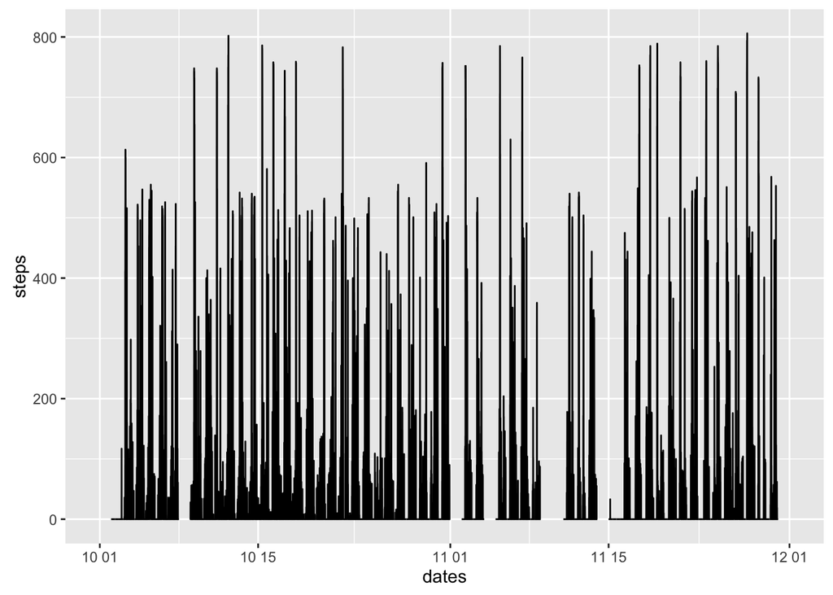

```r
paperrank <- tbl_df(paperrank)
step <- paperrank %>%
        mutate(hours = as.integer(X.interval./100),
               minutes = as.integer(X.interval.%%100)) %>%
        mutate(hm=paste(hours, minutes, "00",sep=":")) %>%
        mutate(times = paste(X.date., hm, sep=" ")) %>%
        select(X.steps., times) %>%
        transform(dates = as.POSIXlt(times)) %>%
        select(X.steps.,dates)
names(step) <- c("steps","dates")
g <- ggplot(step, aes(dates,steps))
g + geom_line()
```

## Third question: Imputing missing values

Calculate and report the total number ofrows with missing value

```r
sum(is.na(paperrank))
```

```
## [1] 2304
```

Strategy of filling missing values: the NA value equal to the mean for that 5-minute interval

New dataset with missing data filled in:

```r
library(dplyr)
library(ggplot2)
paperrank <- tbl_df(paperrank)
intervalmeanstep <- paperrank %>%
        filter(!is.na(X.steps.)) %>%
        group_by(X.interval.) %>%
        summarize( meanstep = mean(X.steps.))
paperrank2 <- paperrank
paperrank3 <- paperrank2 %>%
        filter(is.na(paperrank2$X.steps.))
paperrank3 <- merge(paperrank3, intervalmeanstep, by = "X.interval.")
paperrank3 <- paperrank3 %>%
        mutate(X.steps. = ceiling(meanstep)) %>%
        select(X.steps.,X.date.,X.interval.)

paperrank2 <- rbind(paperrank2[!is.na(paperrank2$X.steps.),],paperrank3)
paperrank2 <- paperrank2 %>%
        arrange(X.date.)
summary(paperrank2)
```

```
##     X.steps.         X.date.            X.interval.
##  Min.   :  0.00   Min.   :2012-10-01   Min.   :   0.0
##  1st Qu.:  0.00   1st Qu.:2012-10-16   1st Qu.: 588.8
##  Median :  0.00   Median :2012-10-31   Median :1177.5
##  Mean   : 37.45   Mean   :2012-10-31   Mean   :1177.5
##  3rd Qu.: 27.00   3rd Qu.:2012-11-15   3rd Qu.:1766.2
##  Max.   :806.00   Max.   :2012-11-30   Max.   :2355.0
```

Plot histogram of the total number of steps taken each day:

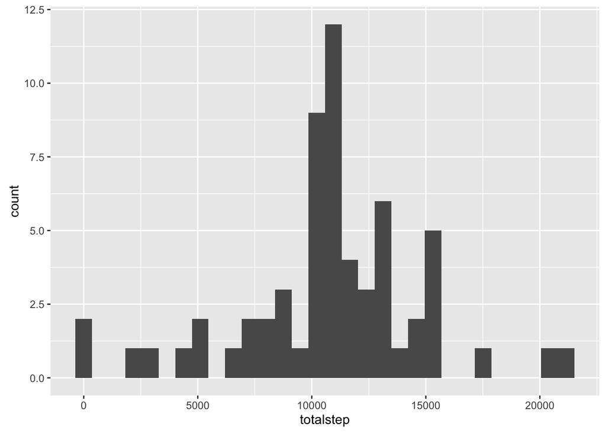

```r
totalstep2 <- paperrank2 %>%
        group_by(X.date.) %>%
        summarize( totalstep = sum(X.steps.))
g <- ggplot(totalstep2,aes(totalstep))
g + geom_histogram()
```

Mean value of this:

```r
as.numeric(summarize(totalstep2, mean = mean(totalstep)))
```

```
## [1] 10784.92
```

Median value of this:

```r
as.numeric(summarize(totalstep2, medain = median(totalstep)))
```

```
## [1] 10909
```

Because the missing data is filled by 5-minute intervals, so the mid part of the histogram increased rapidly. On the other hand, mean and median value changed little.

## Forth question: Are there differences in activity patterns between weekdays and weekends?

divide data set by using two levels: weekday and weekend

```r
library(dplyr)
paperrank2 <- tbl_df(paperrank2)
step2 <- paperrank2 %>%
        mutate(hours = as.integer(X.interval./100),
              minutes = as.integer(X.interval.%%100)) %>%
        mutate(hm=paste(hours, minutes, "00",sep=":")) %>%
        mutate(times = paste(X.date., hm, sep=" ")) %>%
        select(X.steps., times) %>%
        transform(dates = as.POSIXlt(times)) %>%
        select(X.steps.,dates) %>%
        rename(steps = X.steps.)
step2 <- mutate(step2, weekday = weekdays(step2$dates))
step2[step2$weekday %in%
              c("星期一","星期二","星期三","星期四","星期五"),]$weekday <- "weekday"
step2[step2$weekday %in% c("星期六","星期日"),]$weekday <- "weekend"
summary(step2)
```

```
##      steps            dates                       weekday
##  Min.   :  0.00   Min.   :2012-10-01 00:00:00   Length:17568
##  1st Qu.:  0.00   1st Qu.:2012-10-16 05:58:45   Class :character
##  Median :  0.00   Median :2012-10-31 11:57:30   Mode  :character
##  Mean   : 37.45   Mean   :2012-10-31 11:57:30
##  3rd Qu.: 27.00   3rd Qu.:2012-11-15 17:56:15
##  Max.   :806.00   Max.   :2012-11-30 23:55:00
```

draw the picture

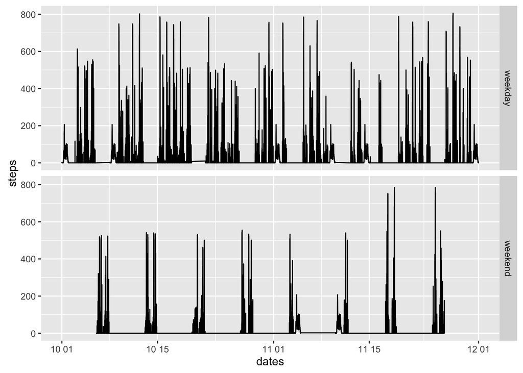

```r
g <- ggplot(step2, aes(dates,steps))
g + geom_line() + facet_grid(weekday~.)
```